# MT_LionelDeLuna_Group_02_ITAI_1378

1. Import necessary libraries

This code sets up the necessary libraries and tools for working with image data, building neural networks, and training models using the CIFAR-10 dataset.

```python
import numpy as np
import tensorflow as tf
from tensorflow.keras.preprocessing.image import ImageDataGenerator
from tensorflow.keras.applications import EfficientNetB0, MobileNetV2
from tensorflow.keras import layers, models
import matplotlib.pyplot as plt
from tensorflow.keras.datasets import cifar10
from sklearn.model_selection import train_test_split
from tensorflow.keras.utils import to_categorical
```

2. Load the CIFAR-10 dataset

This code prepares the CIFAR-10 dataset for training a model by loading the data, normalizing the images, converting labels to a suitable format, and creating a smaller subset for specific tasks.

```python
# Load CIFAR-10 dataset
(X_train, y_train), (X_test, y_test) = cifar10.load_data()

# Normalize the images to range [0, 1]
X_train, X_test = X_train / 255.0, X_test / 255.0

# Convert labels to one-hot encoding
y_train = to_categorical(y_train, 10)
y_test = to_categorical(y_test, 10)

# Split training data into a smaller subset for object detection model (e.g., 10% of the data)
X_train_subset, _, y_train_subset, _ = train_test_split(X_train, y_train, test_size=0.9, random_state=42)
```

3. Remove irrelevant or low-quality images

This code removes all images of the "cat" class from the training dataset, leaving only the images of other classes.

```python
# Example: remove images from a specific class (e.g., class 3, "cat")
filter_class = 3
mask = (y_train_subset.argmax(axis=1) != filter_class)
X_train_subset, y_train_subset = X_train_subset[mask], y_train_subset[mask]
```

4. Data Augmentation

This code sets up an image data generator that applies various augmentations to the training images, helping to create a more diverse dataset for training a model.

```python
# Create ImageDataGenerator with augmentations
datagen = ImageDataGenerator(
    rotation_range=20,      # Random rotations
    width_shift_range=0.2,  # Random horizontal shifts
    height_shift_range=0.2, # Random vertical shifts
    shear_range=0.2,        # Shearing
    zoom_range=0.2,         # Zooming
    horizontal_flip=True,   # Horizontal flips
    brightness_range=[0.8, 1.2],  # Adjust brightness
    fill_mode='nearest'     # Fill missing pixels
)

# Fit the data generator to the training data
datagen.fit(X_train_subset)
```

5. Class Imbalance Handling

This code calculates and formats class weights to address any class imbalance in the training dataset, which can help improve the performance of the model during training.

```python
from sklearn.utils import class_weight

# Find unique classes in y_train_subset
unique_classes = np.unique(y_train_subset.argmax(axis=1))

# Compute class weights based on the unique classes present
class_weights = class_weight.compute_class_weight('balanced', classes=unique_classes, y=y_train_subset.argmax(axis=1))

# Convert class weights to a dictionary format
class_weight_dict = {unique_classes[i]: class_weights[i] for i in range(len(unique_classes))}

# Optionally print class weights to check
print(class_weight_dict)
```

```
{0: 0.9860566448801743, 1: 1.0326260552133242, 2: 1.0017706949977867, 4: 0.9597116200169635, 5: 0.9997791031588248, 6: 0.9958195819581959, 7: 0.9417394923012901, 8: 1.0077933645067914, 9: 1.0885040885040884}
```

6. Build the Baseline Model: EfficientNetB0

This code sets up a neural network model using ENetB0 as a feature extractor, adds additional layers for classification, and prepares the model for training.

```python
# EfficientNetB0 model as a feature extractor (no top layer)
base_model = EfficientNetB0(weights='imagenet', include_top=False, input_shape=(32, 32, 3))

# Freeze base model layers
base_model.trainable = False

# Create the full model
model = models.Sequential([
    base_model,
    layers.GlobalAveragePooling2D(),
    layers.Dense(128, activation='relu'),
    layers.Dense(10, activation='softmax')  # 10 classes in CIFAR-10
])

model.compile(optimizer='adam', loss='categorical_crossentropy', metrics=['accuracy'])
```

7. Train the Model with Augmentation

This code trains a model using augmented training data for 10 epochs, evaluates its performance on a validation dataset, and incorporates class weights to address any class imbalances.

```python
# Train the model using the augmented data
history = model.fit(datagen.flow(X_train_subset, y_train_subset, batch_size=64),
                    steps_per_epoch=len(X_train_subset) // 64,
                    epochs=10,
                    validation_data=(X_test, y_test),
                    class_weight=class_weight_dict)
```

```
70/70 ━━━━━━━━━━━━━━━━━━━━ 29s 273ms/step - accuracy: 0.0952 - loss: 2.2587 - val_accuracy: 0.1000 - val_loss: 2.7440
 1/70 ━━━━━━━━━━━━━━━━━━━━ 4s 70ms/step - accuracy: 0.0781 - loss: 2.2290
```

```
70/70 ━━━━━━━━━━━━━━━━━━━━ 12s 166ms/step - accuracy: 0.0781 - loss: 2.2290 - val_accuracy: 0.1000 - val_loss: 2.7349
70/70 ━━━━━━━━━━━━━━━━━━━━ 16s 226ms/step - accuracy: 0.1091 - loss: 2.2264 - val_accuracy: 0.1000 - val_loss: 2.7772
70/70 ━━━━━━━━━━━━━━━━━━━━ 12s 173ms/step - accuracy: 0.0938 - loss: 2.2014 - val_accuracy: 0.1000 - val_loss: 2.7584
70/70 ━━━━━━━━━━━━━━━━━━━━ 18s 259ms/step - accuracy: 0.1133 - loss: 2.2195 - val_accuracy: 0.1000 - val_loss: 2.7838
70/70 ━━━━━━━━━━━━━━━━━━━━ 12s 169ms/step - accuracy: 0.1094 - loss: 2.2471 - val_accuracy: 0.1000 - val_loss: 2.7771
70/70 ━━━━━━━━━━━━━━━━━━━━ 18s 256ms/step - accuracy: 0.1181 - loss: 2.2143 - val_accuracy: 0.1000 - val_loss: 2.7707
70/70 ━━━━━━━━━━━━━━━━━━━━ 13s 193ms/step - accuracy: 0.1406 - loss: 2.2362 - val_accuracy: 0.1000 - val_loss: 2.7779
70/70 ━━━━━━━━━━━━━━━━━━━━ 20s 288ms/step - accuracy: 0.1080 - loss: 2.2191 - val_accuracy: 0.1000 - val_loss: 2.7655
70/70 ━━━━━━━━━━━━━━━━━━━━ 12s 174ms/step - accuracy: 0.1406 - loss: 2.1622 - val_accuracy: 0.1000 - val_loss: 2.7619
```

8. Build a Lightweight Model: MobileNetV2

This code sets up a neural network model using MobileNetV2 as a feature extractor, adds additional layers for classification, and prepares the model for training.

```python
# MobileNetV2 model as a feature extractor (no top layer)
base_model_mobilenet = MobileNetV2(weights='imagenet', include_top=False, input_shape=(32, 32, 3))

# Freeze base model layers
base_model_mobilenet.trainable = False

# Create the full model
model_mobilenet = models.Sequential([
    base_model_mobilenet,
    layers.GlobalAveragePooling2D(),
    layers.Dense(128, activation='relu'),
    layers.Dense(10, activation='softmax')  # 10 classes in CIFAR-10
])

model_mobilenet.compile(optimizer='adam', loss='categorical_crossentropy', metrics=['accuracy'])
```

9. Train the Lightweight Model

This code trains the MobileNetV2 model using augmented training data for 10 epochs, evaluates its performance on a validation dataset, and incorporates class weights to address any class imbalances.

```python
# Train the MobileNetV2 model with augmented data
history_mobilenet = model_mobilenet.fit(datagen.flow(X_train_subset, y_train_subset, batch_size=64),
                                        steps_per_epoch=len(X_train_subset) // 64,
                                        epochs=10,
                                        validation_data=(X_test, y_test),
                                        class_weight=class_weight_dict)
```

```
70/70 ━━━━━━━━━━━━━━━━━━━━ 21s 218ms/step - accuracy: 0.1026 - loss: 2.2638 - val_accuracy: 0.1081 - val_loss: 2.3571
70/70 ━━━━━━━━━━━━━━━━━━━━ 7s 99ms/step - accuracy: 0.0781 - loss: 2.2309 - val_accuracy: 0.1066 - val_loss: 2.3578
70/70 ━━━━━━━━━━━━━━━━━━━━ 12s 165ms/step - accuracy: 0.1178 - loss: 2.2114 - val_accuracy: 0.1016 - val_loss: 2.4322
70/70 ━━━━━━━━━━━━━━━━━━━━ 8s 109ms/step - accuracy: 0.0625 - loss: 2.2134 - val_accuracy: 0.1016 - val_loss: 2.4338
70/70 ━━━━━━━━━━━━━━━━━━━━ 13s 180ms/step - accuracy: 0.1065 - loss: 2.2023 - val_accuracy: 0.0954 - val_loss: 2.5157
70/70 ━━━━━━━━━━━━━━━━━━━━ 8s 114ms/step - accuracy: 0.1094 - loss: 2.1984 - val_accuracy: 0.0963 - val_loss: 2.5158
70/70 ━━━━━━━━━━━━━━━━━━━━ 14s 204ms/step - accuracy: 0.1104 - loss: 2.1983 - val_accuracy: 0.1005 - val_loss: 2.6235
70/70 ━━━━━━━━━━━━━━━━━━━━ 9s 132ms/step - accuracy: 0.0938 - loss: 2.1926 - val_accuracy: 0.1009 - val_loss: 2.6245
70/70 ━━━━━━━━━━━━━━━━━━━━ 13s 181ms/step - accuracy: 0.1090 - loss: 2.1930 - val_accuracy: 0.0999 - val_loss: 2.7706
70/70 ━━━━━━━━━━━━━━━━━━━━ 8s 116ms/step - accuracy: 0.0781 - loss: 2.2001 - val_accuracy: 0.0997 - val_loss: 2.7715
```

10. Evaluate the Models

This code evaluates and compares the test accuracy of two different models (EfficientNetB0 and MobileNetV2) on the same test dataset, providing insights into their performance.

```python
# Evaluate the EfficientNetB0 model
test_loss, test_acc = model.evaluate(X_test, y_test, verbose=2)
print(f"EfficientNetB0 Test Accuracy: {test_acc}")

# Evaluate the MobileNetV2 model
test_loss_mobilenet, test_acc_mobilenet = model_mobilenet.evaluate(X_test, y_test, verbose=2)
print(f"MobileNetV2 Test Accuracy: {test_acc_mobilenet}")
```

```
313/313 - 12s - 37ms/step - accuracy: 0.1000 - loss: 2.7619
EfficientNetB0 Test Accuracy: 0.10000000149011612
313/313 - 8s - 26ms/step - accuracy: 0.0997 - loss: 2.7715
MobileNetV2 Test Accuracy: 0.09969999641180038
```

11. Plot Training and Validation Accuracy

This code generates two plots: one for the training and validation accuracy of the EfficientNetB0 model and another for the MobileNetV2 model, allowing for a visual comparison of their performance over the training epochs

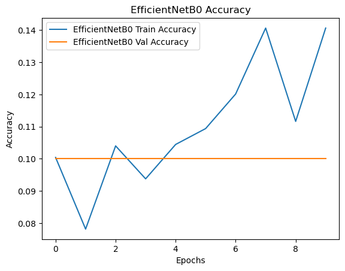

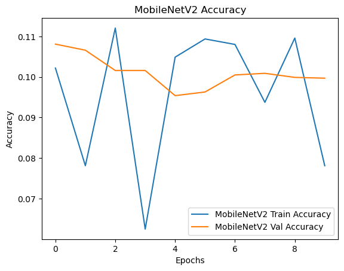

```python
# Plot accuracy for EfficientNetB0
plt.plot(history.history['accuracy'], label='EfficientNetB0 Train Accuracy')
plt.plot(history.history['val_accuracy'], label='EfficientNetB0 Val Accuracy')
plt.title('EfficientNetB0 Accuracy')
plt.xlabel('Epochs')
plt.ylabel('Accuracy')
plt.legend()
plt.show()

# Plot accuracy for MobileNetV2
plt.plot(history_mobilenet.history['accuracy'], label='MobileNetV2 Train Accuracy')
plt.plot(history_mobilenet.history['val_accuracy'], label='MobileNetV2 Val Accuracy')
plt.title('MobileNetV2 Accuracy')
plt.xlabel('Epochs')
plt.ylabel('Accuracy')
plt.legend()
plt.show()
```